# Uterine Leiomyoma Beadchip Gene Expressions

Janis Corona

2/23/2020

This is to re-examine the UL and non-UL samples from the Gene Expression Omnibus online data repository (GEO) for genotypes in the ULs compared to those samples without tumor tissue in them. The accession IDs for the Series is GSE95101 and for the platform is GPL13376

```r
library(dplyr)
library(tidyr)
library(e1071)
library(caret)
library(randomForest)
library(MASS)
library(gbm)
```

```r
UL1a <- read.csv('UL1a.csv', sep=',',
                header=T, na.strings=c('',' '))
UL1b <- read.csv('UL1b.csv', sep=',',
                header=T, na.strings=c('',' '))
UL1c <- read.csv('UL1c.csv', sep=',',
                header=T, na.strings=c('',' '))
UL1d <- read.csv('UL1d.csv', sep=',',
                header=T, na.strings=c('',' '))

UL1 <- rbind(UL1a,UL1b,UL1c,UL1d)
rm(UL1a,UL1b,UL1c,UL1d)
str(UL1)
```

```
## 'data.frame':    48701 obs. of  51 variables:
##  $ X                    : int  1 2 3 4 5 6 7 8 9 10 ...
##  $ ID                   : Factor w/ 48701 levels "ILMN_1343289",..: 1 2 3 4 5 6 7 8 9 10 ...
##  $ Species              : Factor w/ 1 level "Homo sapiens": 1 1 1 1 1 1 1 1 1 1 ...
##  $ Source               : Factor w/ 3 levels "ILMN_Controls",..: 1 1 2 1 1 2 2 2 2 2 ...
##  $ Search_Key           : Factor w/ 46721 levels "ILMN_10001","ILMN_10014",..: 11664 11664 11664 11664 11664 11664 11664 9848 11306 1417 ...
##  $ Transcript           : Factor w/ 46724 levels "ILMN_10001","ILMN_10014",..: 2290 2291 1377 2292 2293 4903 1218 9858 11314 1421 ...
##  $ ILMN_Gene            : Factor w/ 43186 levels "1-Dec","1-Mar",..: 8904 10174 2074 10143 10156 88 2713 4872 9250 2029 ...
##  $ Source_Reference_ID  : Factor w/ 46721 levels "NM_000015.1",..: 776 4636 1225 1123 1827 1130 1438 9379 7158 10894 ...
##  $ RefSeq_ID            : Factor w/ 28570 levels "NM_000015.1",..: 776 4636 1225 1123 1827 1130 1438 9379 7158 10894 ...
##  $ Unigene_ID           : Factor w/ 18153 levels "NA","Hs.100554",..: 1 1 1 1 1 1 1 1 1 1 ...
##  $ Entrez_Gene_ID       : Factor w/ 16063 levels "10","10000","10001",..: 10744 10744 1487 10744 10744 5871 2331 6516 10718 5545 ...
##  $ GI                   : int  14141192 20149305 25453469 4507728 4507744 5016088 7669491 88954077 33469136 89070645 ...
##  $ Accession            : Factor w/ 46721 levels "NM_000015.1",..: 776 4636 1225 1123 1827 1130 1438 9379 7158 10894 ...
##  $ Symbol               : Factor w/ 25036 levels "1-Dec","1-Mar",..: 8904 10174 2074 10143 10156 88 2713 4872 9250 2029 ...
```

[output cut: 37 more lines]

```r
nonUL1a <- read.csv('nonUL1a.csv', sep=',',
                header=T, na.strings=c('',' '))
nonUL1b <- read.csv('nonUL1b.csv', sep=',',
                header=T, na.strings=c('',' '))
nonUL1c <- read.csv('nonUL1c.csv', sep=',',
                header=T, na.strings=c('',' '))
nonUL1d <- read.csv('nonUL1d.csv', sep=',',
                header=T, na.strings=c('',' '))

nonUL1 <- rbind(nonUL1a,nonUL1b,nonUL1c,nonUL1d)

rm(nonUL1a,nonUL1b,nonUL1c,nonUL1d)
str(nonUL1)
```

```
## 'data.frame':    48701 obs. of  49 variables:
##  $ X                    : int  1 2 3 4 5 6 7 8 9 10 ...
##  $ ID                   : Factor w/ 48701 levels "ILMN_1343289",..: 1 2 3 4 5 6 7 8 9 10 ...
##  $ Species              : Factor w/ 1 level "Homo sapiens": 1 1 1 1 1 1 1 1 1 1 ...
##  $ Source               : Factor w/ 3 levels "ILMN_Controls",..: 1 1 2 1 1 2 2 2 2 2 ...
##  $ Search_Key           : Factor w/ 46721 levels "ILMN_10001","ILMN_10014",..: 11664 11664 11664 11664 11664 11664 11664 9848 11306 1417 ...
##  $ Transcript           : Factor w/ 46724 levels "ILMN_10001","ILMN_10014",..: 2290 2291 1377 2292 2293 4903 1218 9858 11314 1421 ...
##  $ ILMN_Gene            : Factor w/ 43186 levels "1-Dec","1-Mar",..: 8904 10174 2074 10143 10156 88 2713 4872 9250 2029 ...
##  $ Source_Reference_ID  : Factor w/ 46721 levels "NM_000015.1",..: 776 4636 1225 1123 1827 1130 1438 9379 7158 10894 ...
##  $ RefSeq_ID            : Factor w/ 28570 levels "NM_000015.1",..: 776 4636 1225 1123 1827 1130 1438 9379 7158 10894 ...
##  $ Unigene_ID           : Factor w/ 18153 levels "NA","Hs.100554",..: 1 1 1 1 1 1 1 1 1 1 ...
##  $ Entrez_Gene_ID       : Factor w/ 16063 levels "10","10000","10001",..: 10744 10744 1487 10744 10744 5871 2331 6516 10718 5545 ...
##  $ GI                   : int  14141192 20149305 25453469 4507728 4507744 5016088 7669491 88954077 33469136 89070645 ...
##  $ Accession            : Factor w/ 46721 levels "NM_000015.1",..: 776 4636 1225 1123 1827 1130 1438 9379 7158 10894 ...
##  $ Symbol               : Factor w/ 25036 levels "1-Dec","1-Mar",..: 8904 10174 2074 10143 10156 88 2713 4872 9250 2029 ...
```

[output cut: 35 more lines]

```r
UL <- UL1[,-c(1:13,15:19,21,29:31)]
nonUL <- nonUL1[,-c(1:13,15:19,21,29:31)]
```

```r
write.csv(UL,'UL.csv', row.names=FALSE)
write.csv(nonUL, 'nonUL.csv', row.names=FALSE)
```

```r
fibroid <- read.csv('UL.csv', sep=',', header=T, na.strings=c('',' '))
nonFibroid <- read.csv('nonUL.csv', sep=',', header=T, na.strings=c('',' '))
```

```r
fibroid_gene_n <- fibroid %>% group_by(Symbol) %>% count(n())
narm <- grep('^NA$',fibroid_gene_n$Symbol)

fibroid1 <- fibroid_gene_n[-narm,-2]
colnames(fibroid1)[2] <- 'gene_count'

NONfibroid_gene_n <- nonFibroid %>% group_by(Symbol) %>% count(n())
narm1 <- grep('^NA$',NONfibroid_gene_n$Symbol)

nonFibroid1 <- NONfibroid_gene_n[-narm1,-2]
colnames(nonFibroid1)[2] <- 'gene_count'

GeneCopyNumberVariants <- fibroid1[order(fibroid1$gene_count,decreasing=TRUE)[1:10],]
GeneCopyNumberVariants
```

```
## # A tibble: 10 x 2
## # Groups:   Symbol [10]
##    Symbol    gene_count
##    <fct>          <int>
##  1 DDX12             10
##  2 KIAA0692           9
##  3 LOC23117           8
##  4 PLEC1              8
##  5 BDNF               7
##  6 CTNNB1             7
##  7 DMD                7
##  8 LOC202134          7
##  9 LOC339047          7
## 10 LOC653086          7
```

Combine the gene counts with the tables of samples for each type of UL or nonUL.

```r
Fibroid_count <- merge(fibroid1, fibroid, by.x='Symbol', by.y='Symbol')
nonFibroid_count <- merge(nonFibroid1, nonFibroid, by.x='Symbol', by.y='Symbol')
Fibroid_count[order(Fibroid_count$gene_count, decreasing=TRUE)[1:20],1:3]
```

```
##         Symbol gene_count                                           SEQUENCE
## 5646     DDX12         10 CCAGTCCCTGACTACAGAGGATTTCCCCAAAGTCCCTGGCTGTGAGGTTC
## 5647     DDX12         10 TTACTGGGGATGGTATTTAGGAGCCAGGAAAGCCGGTGCATTCCTAGTGA
## 5648     DDX12         10 TCTCCTGCCCCCTCCGGAAGCTTGGATGCCCCTCCACACCCTCTTGATCT
## 5649     DDX12         10 CAGACTTCTCGCTTCCTTTCTGCTGGGCCTCTGAGGGGTCATGGGGCCAT
## 5650     DDX12         10 ACATGTGCTGTCACTGGAACTTGCTCTTTTCACTCAGCAGCCAGAGGGTC
## 5651     DDX12         10 AAACGTTACAGTGTTCCGATGAGACACAGTAGGCAGTACTTGGGAGGGTC
## 5652     DDX12         10 CAGGGCAGGAACCACGTCTTTACAGTTTGATGTTCCCAGAGCTGACCCAG
## 5653     DDX12         10 GCAGGGGAGATTGGGTTTAGGGGCTTTCCTGGTCTGCATTCTGCTACAGC
## 5654     DDX12         10 CCGCCGGGCTGCTTTTTCCTTGGATGCCCATCAGGACGCCTCAGTTCTCT
## 5655     DDX12         10 CGTTGCTACAAGCTGTTTTTTGAATGTCTCTACACAGTCCAGGCAGGAAG
## 10983 KIAA0692          9 AAGTGGTGCCTGGCTGTCCCTATACTGTGCTGCTGGGTGTTCCAGCCTGT
## 10984 KIAA0692          9 TAAGTGCAGTGAGCTCTGGCGGAAACCACCCTCTGCCCCGTCTGTTGGAT
## 10985 KIAA0692          9 CATTGTAATGATAAGGAAATGTTGCGATCAAATAAGATTTAGACACACTT
## 10986 KIAA0692          9 GATCACAGGCACAGGGAAGCCACAAGGAGCTCTGTATGAGTTGTGTTTGC
## 10987 KIAA0692          9 CAGGCGACTGGGTAGCAGATGTGGAAGCTGATGGTTAGGCCCAGGGCATG
## 10988 KIAA0692          9 GTTGTTCTGGACGATCTTCGGGATCCTCTGGGGCACTGTGACACTCGGAG
## 10989 KIAA0692          9 GAGTGCTGGGAAGGTTAATGTTAAATGGGTTGTGTGTCGGGGAGGGTACA
## 10990 KIAA0692          9 AGCTCCACCTTGACCCAGCCTCACAACAAAAAGTTTGTGTATGACCAGGC
## 10991 KIAA0692          9 GCAAATGTAACTCAGGGGTTTGGGGCCAGAGGAAGAGGGAGAAGGTGGCC
## 12174 LOC23117          8 CTGGCCTTCCCTCATCAGCCGTAAATGATGATTTACTGCTGTTACCATCA
```

Add a mean, median, min, and max column to these tables.

```r
Fibroid_count$Fibroid_Mean <- rowMeans(Fibroid_count[11:30])
nonFibroid_count$nonFibroid_Mean <- rowMeans(nonFibroid_count[11:28])
```

Use the tidyr package to group by sample ID by gathering those columns into one.

```r
UL_3 <- gather(Fibroid_count, 'UL_Sample_ID','Value',11:30)
nonUL_3 <- gather(nonFibroid_count, 'nonUL_Sample_ID', 'Value',11:28)
```

Create the stat tables then combine for the UL and nonUL sample sets using the dplyr package.

```r
UL_median <- UL_3 %>% group_by(SEQUENCE) %>% summarise_at(vars(Value), median)
colnames(UL_median)[2] <- 'Fibroid_Median'

nonUL_median <- nonUL_3 %>% group_by(SEQUENCE) %>% summarise_at(vars(Value), median)
colnames(nonUL_median)[2] <- 'nonFibroid_Median'

UL_max <- UL_3 %>% group_by(SEQUENCE) %>% summarise_at(vars(Value), max)
colnames(UL_max)[2] <- 'Fibroid_max'

nonUL_max <- nonUL_3 %>% group_by(SEQUENCE) %>% summarise_at(vars(Value), max)
colnames(nonUL_max)[2] <- 'nonFibroid_max'

UL_min <- UL_3 %>% group_by(SEQUENCE) %>% summarise_at(vars(Value), min)
colnames(UL_min)[2] <- 'Fibroid_min'

nonUL_min <- nonUL_3 %>% group_by(SEQUENCE) %>% summarise_at(vars(Value), min)
colnames(nonUL_min)[2] <- 'nonFibroid_min'

UL_sd <- UL_3 %>% group_by(SEQUENCE) %>% summarise_at(vars(Value), sd)
colnames(UL_sd)[2] <- 'Fibroid_stdError'

nonUL_sd <- nonUL_3 %>% group_by(SEQUENCE) %>% summarise_at(vars(Value), sd)
colnames(nonUL_sd)[2] <- 'nonFibroid_stdError'
```

Combine these four tables together.

```r
Fibroid_stats <- merge(UL_median, UL_max, by.x='SEQUENCE', by.y='SEQUENCE')
Fibroid_stats1 <- merge(Fibroid_stats, UL_min, by.x='SEQUENCE', by.y='SEQUENCE')
Fibroid_stats2 <- merge(Fibroid_count, Fibroid_stats1, by.x='SEQUENCE', by.y='SEQUENCE')
Fibroid_stats3 <- merge(Fibroid_stats2, UL_sd, by.x='SEQUENCE', by.y='SEQUENCE')
colnames(Fibroid_stats3)[11:30] <- paste('UL_', colnames(Fibroid_stats3)[11:30], sep='')

nonFibroid_stats <- merge(nonUL_median, nonUL_max, by.x='SEQUENCE', by.y='SEQUENCE')
nonFibroid_stats1 <- merge(nonFibroid_stats, nonUL_min, by.x='SEQUENCE', by.y='SEQUENCE')
nonFibroid_stats2 <- merge(nonFibroid_count, nonFibroid_stats1, by.x='SEQUENCE', by.y='SEQUENCE')
nonFibroid_stats3 <- merge(nonFibroid_stats2, nonUL_sd, by.x='SEQUENCE', by.y='SEQUENCE')
colnames(nonFibroid_stats3)[11:28] <- paste('nonUL_', colnames(nonFibroid_stats3)[11:28], sep='')


nonfibroid <- nonFibroid_stats3[,c(1,11:33)]
all <- merge(Fibroid_stats3, nonfibroid, by.x='SEQUENCE', by.y='SEQUENCE')
str(all)
```

```
## 'data.frame':    30549 obs. of  58 variables:
##  $ SEQUENCE             : Factor w/ 48701 levels "AAAAAACAAAACCGCGCAGCGGAGAACCGGTGCCTGAGTCTCCCAGGGAC",..: 1 4 5 7 8 10 12 13 15 18 ...
##  $ Symbol               : Factor w/ 25036 levels "1-Dec","1-Mar",..: 12031 11383 13002 14397 15611 12721 12474 10953 24822 18000 ...
##  $ gene_count           : int  1 1 1 1 1 1 1 1 1 1 ...
##  $ Probe_Chr_Orientation: Factor w/ 3 levels "-","+","NA": 2 1 2 3 3 2 2 3 1 2 ...
##  $ Probe_Coordinates    : Factor w/ 41351 levels "100000925-100000974",..: 33600 3552 19430 41351 41351 36542 28872 41351 31503 41119 ...
##  $ Cytoband             : Factor w/ 3676 levels "10p11.1d","10p11.21a",..: 3472 3472 3472 3472 3472 293 3472 3472 1261 2180 ...
##  $ Definition           : Factor w/ 46614 levels "{3 region, probe S2} [human, 76N, mammary epithelial cells, mRNA Partial, 339 nt]",..: 33743 33388 39229 37744 38664 34103 33968 35730 29449 21454 ...
##  $ Ontology_Component   : Factor w/ 7849 levels "A 20S multiprotein assembly of total mass about 1.2 MDa that activates dynein-based activity in vivo. A large s"| __truncated__,..: 4150 4150 4150 4150 4150 4150 4150 4150 5434 6267 ...
##  $ Ontology_Process     : Factor w/ 8950 levels "[goid 19642] [evidence IEA]; The chemical reactions and pathways involving carbohydrates, any of a group of org"| __truncated__,..: 2492 2492 2492 2492 2492 2492 2492 2492 8502 3316 ...
##  $ Ontology_Function    : Factor w/ 9453 levels "[goid 15280] [evidence IEA]; Interacting selectively with sodium ions (Na+) [goid 31402] [evidence IEA]",..: 8111 8111 8111 8111 8111 8111 8111 8111 7071 2705 ...
##  $ UL_GSM2496185        : num  49.5 51.2 59.9 312.3 52.3 ...
##  $ UL_GSM2496186        : num  51.5 52.3 64.5 333.3 53.7 ...
##  $ UL_GSM2496187        : num  46.9 49 50.3 331.8 56.4 ...
##  $ UL_GSM2496188        : num  50.1 48.4 52 360.9 51.8 ...
```

[output cut: 44 more lines]

Lets change the ‘fibroid’ in the column names to ‘UL’ for uterine leiomyoma.

```r
colnames(all) <- gsub('Fibroid', 'UL', colnames(all))
```

Reorder the table so that the stats are at the end of the columns.

```r
All <- all[,c(1:10,11:30, 36:53,31:35,54:58)]
str(All)
```

```
## 'data.frame':    30549 obs. of  58 variables:
##  $ SEQUENCE             : Factor w/ 48701 levels "AAAAAACAAAACCGCGCAGCGGAGAACCGGTGCCTGAGTCTCCCAGGGAC",..: 1 4 5 7 8 10 12 13 15 18 ...
##  $ Symbol               : Factor w/ 25036 levels "1-Dec","1-Mar",..: 12031 11383 13002 14397 15611 12721 12474 10953 24822 18000 ...
##  $ gene_count           : int  1 1 1 1 1 1 1 1 1 1 ...
##  $ Probe_Chr_Orientation: Factor w/ 3 levels "-","+","NA": 2 1 2 3 3 2 2 3 1 2 ...
##  $ Probe_Coordinates    : Factor w/ 41351 levels "100000925-100000974",..: 33600 3552 19430 41351 41351 36542 28872 41351 31503 41119 ...
##  $ Cytoband             : Factor w/ 3676 levels "10p11.1d","10p11.21a",..: 3472 3472 3472 3472 3472 293 3472 3472 1261 2180 ...
##  $ Definition           : Factor w/ 46614 levels "{3 region, probe S2} [human, 76N, mammary epithelial cells, mRNA Partial, 339 nt]",..: 33743 33388 39229 37744 38664 34103 33968 35730 29449 21454 ...
##  $ Ontology_Component   : Factor w/ 7849 levels "A 20S multiprotein assembly of total mass about 1.2 MDa that activates dynein-based activity in vivo. A large s"| __truncated__,..: 4150 4150 4150 4150 4150 4150 4150 4150 5434 6267 ...
##  $ Ontology_Process     : Factor w/ 8950 levels "[goid 19642] [evidence IEA]; The chemical reactions and pathways involving carbohydrates, any of a group of org"| __truncated__,..: 2492 2492 2492 2492 2492 2492 2492 2492 8502 3316 ...
##  $ Ontology_Function    : Factor w/ 9453 levels "[goid 15280] [evidence IEA]; Interacting selectively with sodium ions (Na+) [goid 31402] [evidence IEA]",..: 8111 8111 8111 8111 8111 8111 8111 8111 7071 2705 ...
##  $ UL_GSM2496185        : num  49.5 51.2 59.9 312.3 52.3 ...
##  $ UL_GSM2496186        : num  51.5 52.3 64.5 333.3 53.7 ...
##  $ UL_GSM2496187        : num  46.9 49 50.3 331.8 56.4 ...
##  $ UL_GSM2496188        : num  50.1 48.4 52 360.9 51.8 ...
```

[output cut: 44 more lines]

```r
All_stats_only <- All[,c(1,2,3,49:58)]
stats_all <- All_stats_only[!duplicated(All_stats_only),]

stats_all$foldChangeMean_UL_to_nonUL <- stats_all$UL_Mean/stats_all$nonUL_Mean

FoldChangeGenes <- stats_all[order(stats_all$foldChangeMean_UL_to_nonUL,  decreasing=TRUE)[c(1:5,30545:30549)],]

FoldChangeGenes
```

```
##                                                 SEQUENCE   Symbol gene_count
## 16709 GCAACGCTCCTCTGAAATGCTTGTCTTTTTTCTGTTGCCGAAATAGCTGG KIAA1199          1
## 17948 GCCCCAGCAAGCCTCCCTCCATCCTCCAGTGGGAAACTGTTGATGGTGTT     PENK          1
## 22790 GGTATTGCTGATCGTATGCAGAAGGAAATCACTGCTCTGGCTCCTAGCAC     ACTC          1
## 28162 TGCGAGACCTGGGTGTCCAACCTGCGCTACAACCACATGCTGCGGAAGAA     DLK1          2
## 3569  AGGCCCTGGAGGCTGCAACATACCTCAATCCTGTCCCAGGCCGGATCCTC    MMP11          1
## 17565 GCCAACCTCCTCTCACAGCCTCTGTATCTCTGCAGGCCATACTGGTTCCA    ABCA8          1
## 6582  CAGATGTTTTCCCTTGTGGCAGTCTTCAGCCTCCTCTACCCTACATGATC    ADH1A          1
## 8958  CCCAGTGACACTTCAGAGAGCTGGTAGTTAGTAGCATGTTGAGCCAGGCC      FOS          1
## 27542 TGACTGTCCCTGCCAATGCTCCAGCTGTCGTCTGACTCTGGGTTCGTTGG     FOSB          1
## 6881  CAGCTGGGCGATGTGCGAGCTGATAGTGAGCGGCAGAATCAGGAGTACCA    KRT19          1
##         UL_Mean UL_Median     UL_max   UL_min UL_stdError nonUL_Mean
## 16709 3029.4710 2566.7096  6548.8160 156.8375  1948.88193  167.75283
## 17948 1798.4359  237.7790 26134.7105  48.2000  5783.33114  120.28719
## 22790 4693.5182 4880.4535 13992.2647 110.2923  3328.78611  392.30767
```

[output cut: 29 more lines]

```r
str(stats_all)
```

```
## 'data.frame':    30549 obs. of  14 variables:
##  $ SEQUENCE                  : Factor w/ 48701 levels "AAAAAACAAAACCGCGCAGCGGAGAACCGGTGCCTGAGTCTCCCAGGGAC",..: 1 4 5 7 8 10 12 13 15 18 ...
##  $ Symbol                    : Factor w/ 25036 levels "1-Dec","1-Mar",..: 12031 11383 13002 14397 15611 12721 12474 10953 24822 18000 ...
##  $ gene_count                : int  1 1 1 1 1 1 1 1 1 1 ...
##  $ UL_Mean                   : num  49.4 48.4 53.4 486.1 54 ...
##  $ UL_Median                 : num  49.5 48.5 52.1 408.9 53.7 ...
##  $ UL_max                    : num  55.2 52.3 64.5 1218 58.1 ...
##  $ UL_min                    : num  44 43.9 49.6 300.4 49.8 ...
##  $ UL_stdError               : num  2.59 2.3 3.61 214.26 2 ...
##  $ nonUL_Mean                : num  48.1 48 53.5 573.5 52.7 ...
##  $ nonUL_Median              : num  48.5 48.1 54.1 539 52.5 ...
##  $ nonUL_max                 : num  52.6 54.1 56.7 795.4 57.4 ...
##  $ nonUL_min                 : num  42.7 42.7 48 408.1 47.4 ...
##  $ nonUL_stdError            : num  2.46 2.75 2.85 130.03 3.07 ...
##  $ foldChangeMean_UL_to_nonUL: num  1.027 1.007 0.997 0.848 1.024 ...
```

```r
write.csv(stats_all, 'stats_only_UL_nonUL.csv', row.names=FALSE)
```

Combine the table of top and bottom five genes in fold change values of the ratio of UL to non-UL sample means, FoldChangeGenes, with the table of the ten genes having the highest number of copy number variations or genotypes, GeneCopyNumberVariants.

```r
ontology <- nonFibroid[,c(1,6:9)]
gnc <- as.data.frame(GeneCopyNumberVariants)[1]

keyGenes1 <- merge(gnc, stats_all, by.x='Symbol', by.y='Symbol')

keyGenes1a <- merge(keyGenes1, ontology, by.x='Symbol', by.y='Symbol')

keyGenes2 <- merge(FoldChangeGenes, ontology, by.x='Symbol', by.y='Symbol')
keyGenes2a <- keyGenes2[,c(1:3,15:18,4:14)]
keyGenes1b <- keyGenes1a[,c(1:3,15:18,4:14)]

KeyGenes <- rbind(keyGenes2a, keyGenes1b)
KG <- KeyGenes[!duplicated(KeyGenes$SEQUENCE),]
KG1 <- KG[order(KG$foldChangeMean_UL_to_nonUL, decreasing=TRUE),]
KG1[,c(1:3,18)]
```

```
##        Symbol                                           SEQUENCE gene_count
## 8    KIAA1199 GCAACGCTCCTCTGAAATGCTTGTCTTTTTTCTGTTGCCGAAATAGCTGG          1
## 11       PENK GCCCCAGCAAGCCTCCCTCCATCCTCCAGTGGGAAACTGTTGATGGTGTT          1
## 2        ACTC GGTATTGCTGATCGTATGCAGAAGGAAATCACTGCTCTGGCTCCTAGCAC          1
## 4        DLK1 TGCGAGACCTGGGTGTCCAACCTGCGCTACAACCACATGCTGCGGAAGAA          2
## 10      MMP11 AGGCCCTGGAGGCTGCAACATACCTCAATCCTGTCCCAGGCCGGATCCTC          1
## 68     CTNNB1 AGCTGCAGGGGTCCTCTGTGAACTTGCTCAGGACAAGGAAGCTGCAGAAG          7
## 89     CTNNB1 CTGCAGGGGTCCTCTGTGAACTTGCTCAGGACAAGGAAGCTGCAGAAGCT          7
## 82     CTNNB1 AGTCTCTCGTAGTGTTAAGTTATAGTGAATACTGCTACAGCAATTTCTAA          7
## 231       DMD CAGTGTTGGGATCACTCACTTTCCCCCTACAGGACTCAGATCTGGGAGGC          7
## 210       DMD CTCCTCTCAGCTGAACACCCTCCTTTCACTCCCAAATGCAAACAGTCTCT          7
## 96     CTNNB1 GCCTCTTGCACTCTGAATTGGGAATGTTTGCACCACAGTGGGGGGCTTGC          7
## 140     DDX12 CCGCCGGGCTGCTTTTTCCTTGGATGCCCATCAGGACGCCTCAGTTCTCT         10
## 397  LOC23117 TCAACCACATCCTTCAAAAGGACTATGCCTGTTTATAAGCCCAGCTGTTT          8
## 361 LOC202134 GCCAAAGGAATGGGCTCCAGACACCCCCTCTTCCAGAGCAAGGATGAAGG          7
```

[output cut: 161 more lines]

```r
write.csv(KG1,'keyGenes_UL_FCs_CNVs.csv', row.names=FALSE)
```

Order by gene count, then by fold change.

```r
KG2 <- KG1[with(KG1, order(gene_count, foldChangeMean_UL_to_nonUL, decreasing=TRUE)),]
```

Lets add in a fold change of the median value ratios of UL to non-UL samples to compare.

```r
colnames(KG2)[18] <- 'foldChange_Mean'
KG2$foldChange_Median <- KG2$UL_Median/KG2$nonUL_Median
```

Lets look at some of these copy number variants of one gene with seven [copy number variants](https://en.wikipedia.org/wiki/Copy-number_variation) or CNVs and see where the changes in the nucleotide sequences occur. Copy number variations in nucleotides can have short repeats, jumps in sequence, insertions, or deletions of a gene. I have been calling these CNVs [genotypes](https://en.wikipedia.org/wiki/Genotype), which are the traits and alleles responsible for the physical traits or phenotypes of an organism. Some CNVs are responsible for diseases, and in tumors there are many different CNVs that are found to be responsible. A uterine leiomyoma or fibroid is a benign tumor. These samples were taken from uterus tissue with these uternine tumors and the same neighboring uterine tissue without uterine tumors.

```r
CTNNB1 <- subset(KG2, KG2$Symbol=='CTNNB1')
CTNNB1_seq <- CTNNB1[,1:2]
```

Add in a column to describe the length of the nucleotides in each copy number variant nucleotide strand.

```r
CTNNB1_seq$SEQUENCE <- as.character(CTNNB1$SEQUENCE)

CTNNB1_seq$nChar <- nchar(CTNNB1_seq$SEQUENCE)
```

Lets look at the CNVs of the CTNNB1 gene.

```r
CTNNB1_seq
```

```
##     Symbol                                           SEQUENCE nChar
## 68  CTNNB1 AGCTGCAGGGGTCCTCTGTGAACTTGCTCAGGACAAGGAAGCTGCAGAAG    50
## 89  CTNNB1 CTGCAGGGGTCCTCTGTGAACTTGCTCAGGACAAGGAAGCTGCAGAAGCT    50
## 82  CTNNB1 AGTCTCTCGTAGTGTTAAGTTATAGTGAATACTGCTACAGCAATTTCTAA    50
## 96  CTNNB1 GCCTCTTGCACTCTGAATTGGGAATGTTTGCACCACAGTGGGGGGCTTGC    50
## 61  CTNNB1 CAAACTTTACAGAGGAGAATGCCCTGTTTGTTAACCATGTTTCTTTTGGC    50
## 75  CTNNB1 CAGGAATCTAGTCTGGATGACTGCTTCTGGAGCCTGGATGCAGTACCATT    50
## 103 CTNNB1 GCAATTTGCCAAGTTTCTTTAGCATTTGGCCCTGGATTACGCTGGACCCC    50
```

From the above, some of the CNVs make you wonder if they are even the same gene. The first two have the same pattern of ‘CTGCAGGG’ then some variations. Then its not obvious what the other sequence alignments are. We could go back to the cytoband location and where the gene starts to see if there is more information.

Lets get the SEQUENCE, protein product, and cytoband columns from the original UL1 table.

```r
cytoband <- UL1[,c(15,20,24)]
```

Now combine with the CTNNB1_seq and the KG2 table.

```r
CTNNB1_cyto <- merge(cytoband, CTNNB1_seq, by.x='SEQUENCE', by.y='SEQUENCE')
KG2_cyto <- merge(cytoband, KG2, by.x='SEQUENCE', by.y='SEQUENCE')
```

Now lets look at the KG2_cyto table to see where these CNVs are located within the cytoband of each gene location.

```r
KG3 <- KG2_cyto[with(KG2_cyto, order(gene_count,foldChange_Mean, decreasing = TRUE)),]
KG3[,1:5]
```

```
##                                              SEQUENCE Protein_Product
## 37 CCGCCGGGCTGCTTTTTCCTTGGATGCCCATCAGGACGCCTCAGTTCTCT     XP_936926.1
## 56 GCAGGGGAGATTGGGTTTAGGGGCTTTCCTGGTCTGCATTCTGCTACAGC     XP_937020.1
## 26 CAGGGCAGGAACCACGTCTTTACAGTTTGATGTTCCCAGAGCTGACCCAG     XP_936919.1
## 77 TCTCCTGCCCCCTCCGGAAGCTTGGATGCCCCTCCACACCCTCTTGATCT     XP_936947.1
## 41 CGTTGCTACAAGCTGTTTTTTGAATGTCTCTACACAGTCCAGGCAGGAAG     XP_937000.1
## 20 CAGACTTCTCGCTTCCTTTCTGCTGGGCCTCTGAGGGGTCATGGGGCCAT     XP_936988.1
## 84 TTACTGGGGATGGTATTTAGGAGCCAGGAAAGCCGGTGCATTCCTAGTGA     XP_936932.1
## 6  ACATGTGCTGTCACTGGAACTTGCTCTTTTCACTCAGCAGCCAGAGGGTC     XP_936976.1
## 30 CCAGTCCCTGACTACAGAGGATTTCCCCAAAGTCCCTGGCTGTGAGGTTC     XP_936952.1
## 1  AAACGTTACAGTGTTCCGATGAGACACAGTAGGCAGTACTTGGGAGGGTC     XP_936980.1
## 72 TAAGTGCAGTGAGCTCTGGCGGAAACCACCCTCTGCCCCGTCTGTTGGAT     XP_935983.1
## 28 CATTGTAATGATAAGGAAATGTTGCGATCAAATAAGATTTAGACACACTT     XP_935991.1
## 49 GAGTGCTGGGAAGGTTAATGTTAAATGGGTTGTGTGTCGGGGAGGGTACA     XP_935974.1
## 51 GCAAATGTAACTCAGGGGTTTGGGGCCAGAGGAAGAGGGAGAAGGTGGCC     XP_935936.1
```

[output cut: 161 more lines]

```r
CTNNB1_b <- subset(KG3, KG3$Symbol=='CTNNB1')
CTNNB1_b[,c(1:5,20:21)]
```

```
##                                              SEQUENCE Protein_Product Cytoband
## 11 AGCTGCAGGGGTCCTCTGTGAACTTGCTCAGGACAAGGAAGCTGCAGAAG     XP_950743.1  3p22.1b
## 44 CTGCAGGGGTCCTCTGTGAACTTGCTCAGGACAAGGAAGCTGCAGAAGCT     NP_001895.1  3p22.1b
## 13 AGTCTCTCGTAGTGTTAAGTTATAGTGAATACTGCTACAGCAATTTCTAA     NP_001895.1  3p22.1b
## 60 GCCTCTTGCACTCTGAATTGGGAATGTTTGCACCACAGTGGGGGGCTTGC     XP_950747.1  3p22.1b
## 19 CAAACTTTACAGAGGAGAATGCCCTGTTTGTTAACCATGTTTCTTTTGGC     XP_950746.1  3p22.1b
## 24 CAGGAATCTAGTCTGGATGACTGCTTCTGGAGCCTGGATGCAGTACCATT     XP_950748.1  3p22.1b
## 53 GCAATTTGCCAAGTTTCTTTAGCATTTGGCCCTGGATTACGCTGGACCCC     XP_947138.1  3p22.1b
##    Symbol gene_count foldChange_Mean foldChange_Median
## 11 CTNNB1          7       1.5689829         1.5744314
## 44 CTNNB1          7       1.5248323         1.4655024
## 13 CTNNB1          7       1.2503004         1.1602376
## 60 CTNNB1          7       1.1098758         1.0850642
## 19 CTNNB1          7       1.0740152         1.0471422
## 24 CTNNB1          7       0.9977081         0.9924948
## 53 CTNNB1          7       0.9930219         0.9818097
```

Lets order the key genes by fold change median then by CNVs.

```r
KG4 <- KG3[with(KG3, order(foldChange_Median, gene_count, decreasing = TRUE)),]
KG4[,c(1:5,21)]
```

```
##                                              SEQUENCE Protein_Product
## 52 GCAACGCTCCTCTGAAATGCTTGTCTTTTTTCTGTTGCCGAAATAGCTGG     NP_061159.1
## 68 GGTATTGCTGATCGTATGCAGAAGGAAATCACTGCTCTGGCTCCTAGCAC     NP_005150.1
## 12 AGGCCCTGGAGGCTGCAACATACCTCAATCCTGTCCCAGGCCGGATCCTC     NP_005931.2
## 81 TGCGAGACCTGGGTGTCCAACCTGCGCTACAACCACATGCTGCGGAAGAA     NP_003827.3
## 59 GCCCCAGCAAGCCTCCCTCCATCCTCCAGTGGGAAACTGTTGATGGTGTT     NP_006202.1
## 11 AGCTGCAGGGGTCCTCTGTGAACTTGCTCAGGACAAGGAAGCTGCAGAAG     XP_950743.1
## 44 CTGCAGGGGTCCTCTGTGAACTTGCTCAGGACAAGGAAGCTGCAGAAGCT     NP_001895.1
## 43 CTCCTCTCAGCTGAACACCCTCCTTTCACTCCCAAATGCAAACAGTCTCT     NP_004010.1
## 13 AGTCTCTCGTAGTGTTAAGTTATAGTGAATACTGCTACAGCAATTTCTAA     NP_001895.1
## 27 CAGTGTTGGGATCACTCACTTTCCCCCTACAGGACTCAGATCTGGGAGGC     NP_003997.1
## 60 GCCTCTTGCACTCTGAATTGGGAATGTTTGCACCACAGTGGGGGGCTTGC     XP_950747.1
## 74 TCAACCACATCCTTCAAAAGGACTATGCCTGTTTATAAGCCCAGCTGTTT     XP_938957.1
## 10 AGCTCCACCTTGACCCAGCCTCACAACAAAAAGTTTGTGTATGACCAGGC     XP_935967.1
## 19 CAAACTTTACAGAGGAGAATGCCCTGTTTGTTAACCATGTTTCTTTTGGC     XP_950746.1
```

[output cut: 161 more lines]

The above table gives the protein products, the ontology function, the fold change of the median values of UL/nonUL, gene symbol, sequence of CNV, and cytoband location. The protein products can be found at genecards.org by entering the ID for the protein product into the search bar. A quick scan of a few of the protein products in genecards.org gave the following descriptions. The first listed protein NP_061159.1 says it is a colon cancer secreted protein. Many of the above CNVs are listed as proteins involved in the extracellular matrix like DMD and CTNNB1. There are also various neurological and synapses diseases associated with those proteins.

The site genecards.org has very useful properties in analyzing gene expression data from this research. If you are a member, you can download the network genes involved in diseases you query and compare to how the genes in certain tissues compare to those genes. Three out of the seven CNVs for CTNNB1 are in the top fold change median values in the ratio of UL/nonUL samples.

```r
write.csv(KG4, 'keyGenes_topMedFCs.csv', row.names=FALSE)
```

Lets make a machine learning data set to test various algorithms on predicting if the sample is a UL or not. We will use the samples in this set, plus add in some microarray samples that have been studied by me elsewhere using this set of genes and sequences if available in any of the microarray studies.

Lets isolate those genes that are in our key genes of top picks for UL targets and combine the UL and nonUL sample information to those genes and sequences without the stats.

```r
keyTargets <- KG4[,c(1,4)]

ULs <- UL[,c(2,10:29)]
colnames(ULs)[2:21] <- paste('UL', colnames(ULs)[2:21], sep='_')

nonULs <- nonUL[,c(2,10:27)]
colnames(nonULs)[2:19] <- paste('nonUL', colnames(nonULs)[2:19], sep='_')

keyULs <- merge(keyTargets, ULs, by.x='SEQUENCE', by.y='SEQUENCE')
keys <- merge(keyULs, nonULs, by.x='SEQUENCE', by.y='SEQUENCE')

write.csv(keys,'keyGeneTargetsCNVs.csv',row.names=FALSE)
```

Lets create the matrix for machine learning.

```r
keys_ml <- as.data.frame(t(keys))
colnames(keys_ml) <- paste(keys$Symbol,keys$SEQUENCE,sep='_')
keys_ml1 <- keys_ml[-(1:2),]
keys_ml1$Type <- as.factor(c(rep('UL',length(grep('^UL_',row.names(keys_ml1)))),
                   rep('nonUL',length(grep('^nonUL_',row.names(keys_ml1))))))
keys_ml2 <- keys_ml1[,c(88,1:87)]

write.csv(keys_ml2, 'ml_ready_UL_classes.csv',row.names=TRUE)
```

Now, lets pull in the other data sets that are from the microarray samples and see if we can get the genes and sequences that correspond to our key genes above in identifying a sample as UL or not with predictive analytics.

There is one study of the other studies that has Sequence, Gene symbol and a few UL and nonUL microarray samples to compare to this above beadchip UL and nonUL set. The GEO series ID is GSE68295 with the GEO platform of GPL6480. The files are 27 MB each in file size.

```r
setwd('./microArray UL')

non <- read.csv('nonUL_GSE68295_GPL6480_table.csv', sep=',',
                header=T, na.strings=c('',' '))
uls <- read.csv('UL_GSE68295_GPL6480_table.csv', sep=',',
                header=T, na.strings=c('',' '))
setwd('../')
```

Keep only the needed columns.

```r
uls_array <- uls[,c(8,18:21)]
colnames(uls_array)[3:5] <- paste('UL', colnames(uls_array)[3:5], sep='_')

non_array <- non[,c(8,18:21)]
colnames(non_array)[3:5] <- paste('nonUL', colnames(non_array)[3:5], sep='_')
```

The sequences don’t align or match any in the microarrays with the beadchip UL samples.

```r
uls_array0 <- merge(keyTargets, uls_array, by.x='SEQUENCE', by.y='SEQUENCE')
ulsArray0 <- uls_array0[,-2]
```

Match by gene symbol between the microarray and beadchip UL samples.

```r
uls_array1 <- merge(keyTargets, uls_array, by.x='Symbol', by.y='GENE_SYMBOL')
ulsArray <- uls_array1[,-2]
```

The sequences don’t align between the arrays and beadchip samples for nonULs.

```r
non_array0 <- merge(keyTargets, non_array, by.x='SEQUENCE', by.y='SEQUENCE')
nonArray0 <- non_array0[,-(1:2)]
```

Match by Gene symbol between the microarray and beadchip samples of nonULs.

```r
non_array1 <- merge(keyTargets, non_array, by.x='Symbol', by.y='GENE_SYMBOL')
nonArray <- non_array1[,-(1:2)]
```

Combine the UL and nonUL samples of the microarrays into one dataset.

```r
microarrays <- merge(ulsArray, nonArray, by.x='SEQUENCE.y', by.y='SEQUENCE.y')
Marrays <- microarrays[!duplicated(microarrays$SEQUENCE),]
```

Since these two expression types can’t be compared by sequence, they should be compared by gene. Lets combine them into a study by gene expression values.

```r
keys1 <- keys[,-1]
keys2 <- keys1 %>% group_by(Symbol) %>%
  summarise_at(vars(as.vector(colnames(keys1)[2:39])), mean)

Marrays1 <- Marrays[,-1]
Marrays2 <- Marrays1 %>% group_by(Symbol) %>%
  summarise_at(vars(as.vector(colnames(Marrays1)[2:7])), mean)

beadArrays <- merge(keys2, Marrays2, by.x='Symbol', by.y='Symbol')
```

There are only 12 genes in common among these combined samples of microarray and beadchip UL and nonUL samples.

```r
beadArrays_ML <- as.data.frame(t(beadArrays))
colnames(beadArrays_ML) <- beadArrays$Symbol
beadArrays_ML2 <- beadArrays_ML[-1,]
beadArrays_ML2$Type <- as.factor(c(rep('UL_bead',20), rep('nonUL_bead',18),
                         rep('UL_array',3), rep('nonUL_array',3)))
beadArrays_ML3 <- beadArrays_ML2[,c(13,1:12)]
```

```r
UL_seq_ML <- keys_ml2
UL_gene_ML <- beadArrays_ML3
```

The libraries were installed earlier.

```r
set.seed(02242020)
```

```r
inTrain <- createDataPartition(y=UL_seq_ML$Type, p=0.7, list=FALSE)

trainingSet <- UL_seq_ML[inTrain,]
testingSet <- UL_seq_ML[-inTrain,]
```

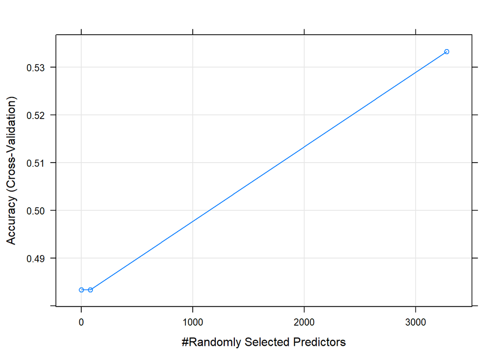

```r
rfMod <- train(Type~., method='rf', data=(trainingSet),
               trControl=trainControl(method='cv'), number=5)
plot(rfMod)
```

Run predictions on the testing set

```r
predRF <- predict(rfMod, testingSet)

predDF <- data.frame(predRF, type=testingSet$Type)
predDF
```

```
##    predRF  type
## 1      UL    UL
## 2      UL    UL
## 3      UL    UL
## 4      UL    UL
## 5      UL    UL
## 6      UL    UL
## 7      UL nonUL
## 8      UL nonUL
## 9      UL nonUL
## 10     UL nonUL
## 11     UL nonUL
```

```r
sum <- sum(predRF==testingSet$Type)
length <- length(testingSet$Type)
accuracy_rfMod <- (sum/length)
accuracy_rfMod
```

```
## [1] 0.5454545
```

```r
results <- c(round(accuracy_rfMod,2), round(100,2))
results <- as.factor(results)
results <- t(data.frame(results))

colnames(results) <- colnames(predDF)
Results <- rbind(predDF, results)
Results
```

```
##         predRF  type
## 1           UL    UL
## 2           UL    UL
## 3           UL    UL
## 4           UL    UL
## 5           UL    UL
## 6           UL    UL
## 7           UL nonUL
## 8           UL nonUL
## 9           UL nonUL
## 10          UL nonUL
## 11          UL nonUL
## results   0.55   100
```

What if we used random forest to only predict by gene in the first beadchip type data set? We can use the transpose of the keys2 data set made earlier when combining to make the 2nd ML dataset.

```r
keys_t <- as.data.frame(t(keys2))
colnames(keys_t) <- keys2$Symbol
keys_t1 <- keys_t[-1,]
keys_t1$Type <- keys_ml2$Type
keys_ML <- keys_t1[,c(21,1:20)]
```

Now we will use our new data set based on the beadchip genes and not the CNVs of those genes, in the keys_ML data set to predict with RandomForest.

```r
inTrain <- createDataPartition(y=keys_ML$Type, p=0.7, list=FALSE)

trainingSet <- keys_ML[inTrain,]
testingSet <- keys_ML[-inTrain,]
```

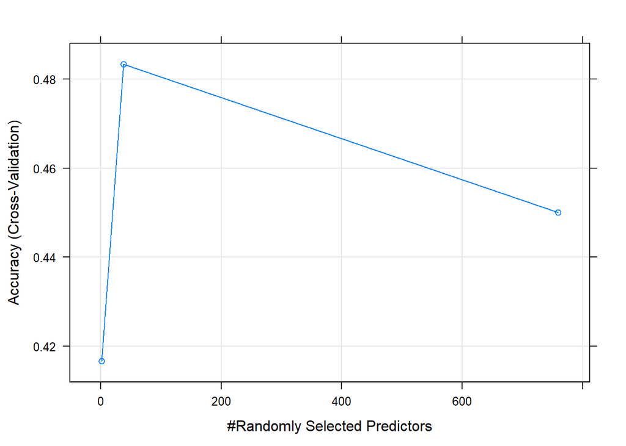

```r
rfMod <- train(Type~., method='rf', data=(trainingSet),
               trControl=trainControl(method='cv'), number=5)
plot(rfMod)
```

Run predictions on the testing set

```r
predRF <- predict(rfMod, testingSet)

predDF <- data.frame(predRF, type=testingSet$Type)
predDF
```

```
##    predRF  type
## 1      UL    UL
## 2      UL    UL
## 3      UL    UL
## 4      UL    UL
## 5      UL    UL
## 6      UL    UL
## 7      UL nonUL
## 8      UL nonUL
## 9      UL nonUL
## 10     UL nonUL
## 11     UL nonUL
```

```r
sum <- sum(predRF==testingSet$Type)
length <- length(testingSet$Type)
accuracy_rfMod <- (sum/length)
accuracy_rfMod
```

```
## [1] 0.5454545
```

```r
results <- c(round(accuracy_rfMod,2), round(100,2))
results <- as.factor(results)
results <- t(data.frame(results))

colnames(results) <- colnames(predDF)
Results <- rbind(predDF, results)
Results
```

```
##         predRF  type
## 1           UL    UL
## 2           UL    UL
## 3           UL    UL
## 4           UL    UL
## 5           UL    UL
## 6           UL    UL
## 7           UL nonUL
## 8           UL nonUL
## 9           UL nonUL
## 10          UL nonUL
## 11          UL nonUL
## results   0.55   100
```

How about with the KNN algorithm.

```r
knnMod <- train(Type ~ .,
                method='knn', preProcess=c('center','scale'),
                tuneLength=10, trControl=trainControl(method='cv'), data=trainingSet)
```

[output not shown]

[output cut: 624 more lines]

[output not shown]

[output not shown]

[output cut: 614 more lines]

[output not shown]

[output not shown]

[output cut: 584 more lines]

[output not shown]

[output not shown]

[output cut: 624 more lines]

[output not shown]

[output not shown]

[output cut: 604 more lines]

[output not shown]

[output not shown]

[output cut: 584 more lines]

[output not shown]

[output not shown]

[output cut: 624 more lines]

[output not shown]

[output not shown]

[output cut: 574 more lines]

[output not shown]

[output not shown]

[output cut: 634 more lines]

[output not shown]

[output not shown]

[output cut: 634 more lines]

[output not shown]

[output not shown]